# Practical Deep Learning

## Getting your deep neural network into a car

Sander van Dijk @ Parkopedia

3 May 2018

# Schedule

- Introductions (15 min – presentation & interactive discussion)
- Introduction to Deep Learning (30 min – presentation)
- CNN Computation Costs (30 min – exercise)
- Break (45 min)
- Fast networks, optimisation tools and tricks (30 min – presentation)
- End-to-End SDC Network (45 min – exercise)
- Wrap-up and take-away notes (15 min – presentation & interactive discussion)

# About me

- MSc in AI @ University of Groningen, NL, 2008
- PhD in AI/CS @ University of Hertfordshire, UK, 2013:  
  Information Theory, Artificial Life
- Into RoboCup since 2006
- Head of Research @ Parkopedia, joined 2013

# RoboCup: Like SDC but With More Falling

```python
YouTubeVideo('pzYHAp7b7sY', width=800, height=480)
```

[video not shown]

# Hardware: Octa-Core Mobile ARM

[figure not shown]

# Deep Learning on Minimal Hardware

[figure not shown]

[figure not shown]

# Ball Segmentation: Real Time Performance

[figure not shown]

# Parkopedia

- Founded 10 years ago
- Now: global leader in digital parking services for automotive
- 8000 cities, 60 million parking spaces
- Research driven:
  - Predicitve parking availability ML models
  - DL for automated discovery and attribute extraction
  - *Autonomous Valet Parking*

# SDC @ Parkopedia: Autonomous Valet Parking

[figure not shown]

# SDC @ Parkopedia: Autonomous Valet Parking

[figure not shown]

# What's Deep Learning?

[figure not shown]

- *Neural network with more than 1 hidden layer*
- Decades old
- Now booming thanks to breakthroughs in:
  - Hardware (GPUs)
  - Large data sets
  - Some theoretical architecture/training advances

# Deep Learning Achievements: ImageNet

[figure not shown]

# Deep Learning Achievements: ImageNet

[figure not shown]

# Deep Learning Achievements: AlphaGo

[figure not shown]

Source: Mastering the game of Go with deep neural networks and tree search, Silver et al, Nature, 2016

# Deep Learning Achievements: AlphaGo

# Deep Learning Achievements: Translation

[figure not shown]

Source: [Google research blog](https://research.googleblog.com/2016/09/a-neural-network-for-machine.html)

# Deep Learning Achievements: Translation

[figure not shown]

# But At What Cost??

**Training: huge GPU (/TPU) clusters**

[figure not shown]

OK, we can live with that, as long as we can run it in our car. Can we...?

# But At What Cost??

- **SENet** (ImageNet 2017):

  > 209 ms on a server with 8 NVIDIA Titan X GPUs
- **AlphaGo**

[figure not shown]

- **GNMT**

  Trained on 12 machines, no info on runtime, but it's Google...

# That's a Lot of Computation..

[figure not shown]

# That's a Lot of Computation..

[figure not shown]

# DL Tasks for Self Driving Cars

- **Object Detection** - Find bounding boxes of objects in an image (and what kind of objects they are)
- **Image Segmentation** - What kind of object does each pixel belong to?
- **Object Segmentation** - Which pixels belong to the same object (and what kind of object is that)?
- Reinforcement Learning - What actions should de car perform?
- Human Sensing - Is the driver paying attention?

Image classificaction, not so much

# DL Tasks for SDCs: Object Detection

```python
YouTubeVideo('_kxX09i4fds', width=800, height=480)
```

[video not shown]

# DL Tasks for SDCs: Object Detection

[figure not shown]

Source: [Karol Majek](https://github.com/karolmajek/darknet) - YOLO9000

# DL Tasks for SDCs: Semantic Segmentation

```python
YouTubeVideo('Nok6Xludc_Q', width=800, height=480)
```

[video not shown]

# DL Tasks for SDCs: Semantic Segmentation

[figure not shown]

Source: http://abhijitkundu.info/projects/fso/

# DL Tasks for SDCs: Object Segmentation

```python
YouTubeVideo('OOT3UIXZztE', width=800, height=480)
```

[video not shown]

# DL Tasks for SDCs: Object Segmentation

[figure not shown]

Source: [Karol Majek](https://github.com/karolmajek/darknet) - Mask-RCNN

[figure not shown]

Source: [MIT 6.S094: Deep Learning for Self-Driving Cars](https://selfdrivingcars.mit.edu/)

# How to Choose a Network?

## *Problem Fit*

But:

- Do you need DL all the way?
- Computation vs Performance

# Computation vs Performance

[figure not shown]

# Computation vs Performance

[figure not shown]

# Operation Costs: Convolution

[figure not shown]

Source: [MachineThink](http://machinethink.net/blog/googles-mobile-net-architecture-on-iphone/)

# Exercise 1

## CNN Computation Costs

https://tinyurl.com/sdtd-dl-1

# Operation Costs: Convolution

[figure not shown]

- A $W \times H$ input tensor (image)...
- with $C$ features (channels)...
- is convolved with $F$ ...
- $N \times N$ kernels

Total number of operations (Multiply-Accumulate, MACs):

$W \times H \times C \times F \times N^2$

# Operation Costs: Convolution

- **2 convs are better than 1**

  Convolution is *associative*: $ f \otimes (g \otimes h) = (f \otimes g) \otimes h $

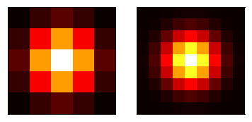

```python
gaussian5x5 = gaussian2d(5, 1)
gaussian9x9 = gaussian2d(9, sqrt(2))
show_kernels([gaussian5x5, gaussian9x9])
```

# Operation Costs: Convolution

- **2 convs are better than 1**

  Convolution is *associative*: $ f \otimes (g \otimes h) = (f \otimes g) \otimes h $

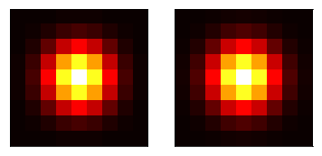

```python
convolved_gaussian = convolve2d(gaussian5x5, gaussian5x5)

show_kernels([convolved_gaussian, gaussian9x9])
```

# Operation Costs: Convolution

- **2 convs are better than 1**

  Convolution is *associative*: $ f \otimes (g \otimes h) = (f \otimes g) \otimes h $
- Instead of 5x5 conv layer, use 2 3x3 layers: 18 instead of 25 operations
- Consideration in 3D:

  $W \times H \times C \times F \times 3^2 + W \times H \times \color{red}{F} \times F \times 3^2$

  or:

  $W \times H \times C \times \color{red}C \times 3^2 + W \times H \times C \times F \times 3^2$

# Operation Costs: Convolution

- **2 convs are better than 1, act 2**

  Convolution as *matrix product*: $ f \otimes (g \times h) = f \otimes (g \otimes h) $

```python
row_vec = [[1, 0, -1]]
col_vec = [[1], [2], [1]]
print('Convolution:'); print_ar( convolve2d(col_vec, row_vec) )
print('Matrix multiplication:'); print_ar( np.outer(col_vec, row_vec) );
```

```
Convolution:
┌───┬───┬────┐
│ 1 │ 0 │ -1 │
├───┼───┼────┤
│ 2 │ 0 │ -2 │
├───┼───┼────┤
│ 1 │ 0 │ -1 │
└───┴───┴────┘
Matrix multiplication:
┌───┬───┬────┐
│ 1 │ 0 │ -1 │
├───┼───┼────┤
│ 2 │ 0 │ -2 │
├───┼───┼────┤
│ 1 │ 0 │ -1 │
└───┴───┴────┘
```

# Operation Costs: Convolution

- **2 convs are better than 1, act 2**

  Convolution as *matrix product*: $ f \otimes (g \times h) = f \otimes (g \otimes h) $
- Depthwise separable: break down 3D in first 2D, then depth

# Operation Costs: Convolution

- **2 convs are better than 1, act 2**

  Convolution as *matrix product*: $ f \otimes (g \times h) = f \otimes (g \otimes h) $

[figure not shown]

- Cost, instead of:

  $W \times H \times C \times F \times N^2$

  now:

  $W \times H \times C \times N^2 + W \times H \times C \times F $

  reduction: $\color{red}{1 / F + 1 / N^2} $

# Operation Costs: Fully Connected Layers

- Used in: classification, object detection, reinforcement learning
- Flatten full image/feature map into 1D array
- Cost:

  $W \times H \times C \times M$

  but commonly: $M > W \times H \times C$
- Downsides:
  - Bulk of computation in shallower networks
  - Loss of spatial structure
  - Fixes network input sizes

# More Ideas: ResNet Bottleneck

[figure not shown]

# More Ideas: Discretisation

- Rather than floating point, use integers
- XNOR-net (runtime), DoReFa (runtime + training)
- Opportunity for highly optimised integer operations
- But: some required operations not native on all platforms

# Exercise 2

## End-to-End SDC Network

https://tinyurl.com/sdtd-dl-2

# Analyse and Optimise Post-Training

Several tools informing you about your network; focussing on TensorFlow:

- TensorBoard: network layout
- Keras: network architecture, number of parameters
- TensorFlow C++ tools:
  - Describe graph
  - Benchmark model
- XLA
- TensorRT

# TensorFlow C++ Tools: Benchmark

- Git clone, install/build Bazel, build tools...
- Bit easier: using Makefile[1]

```python
%bash
cd $HOME/repos && git clone https://github.com/tensorflow/tensorflow
cd tensorflow
tensorflow/contrib/makefile/download_dependencies.sh
tensorflow/contrib/makefile/build_all_linux.sh
```

```python
%%bash
export LD_LIBRARY_PATH=$HOME/repos/tensorflow/tensorflow/contrib/makefile/gen/protobuf/lib/
$HOME/repos/tensorflow/tensorflow/contrib/makefile/gen/bin/benchmark \
  --graph=$HOME/graphs/inception/tensorflow_inception_graph.pb \
  --input_layer="input" --input_layer_shape="1,224,224,3" --input_layer_type="float" --output_layer="output" \
  --show_flops=true \
 2>&1 >/dev/null | cut -f 5- -d ' ' > benchmark1.out.txt
```

[1] https://github.com/tensorflow/tensorflow/tree/master/tensorflow/contrib/makefile

# TensorFlow C++ Tools: Optimise

- `transform_graph`[1] - need Bazel after all..

```python
%%bash
cd $HOME/repos/tensorflow
bazel build tensorflow/tensorflow/tools/graph_transforms:transform_graph &>/dev/null
bazel-bin/tensorflow/tools/graph_transforms/transform_graph \
--in_graph=$HOME/graphs/inception/tensorflow_inception_graph.pb \
--out_graph=$HOME/graphs/inception/optimized_inception_graph.pb \
--inputs='input' \
--outputs='output' \
--transforms='
  strip_unused_nodes(type=float, shape="1,224,224,3")
  remove_nodes(op=Identity, op=CheckNumerics)
  fold_constants(ignore_errors=true)
  fold_batch_norms
  fold_old_batch_norms' &>/dev/null
```

[1] https://github.com/tensorflow/tensorflow/tree/master/tensorflow/tools/graph_transforms

# TensorFlow C++ Tools: Optimise

```python
%%bash
export LD_LIBRARY_PATH=$HOME/repos/tensorflow/tensorflow/contrib/makefile/gen/protobuf/lib/
$HOME/repos/tensorflow/tensorflow/contrib/makefile/gen/bin/benchmark \
  --graph=$HOME/graphs/inception/tensorflow_inception_graph.pb \
  --input_layer="input" --input_layer_shape="1,224,224,3" --input_layer_type="float" --output_layer="output" \
  --show_flops=true \
 2>&1 >/dev/null | cut -f 5- -d ' ' | tail -n 2
```

```
FLOPs estimate: 3.19B
FLOPs/second: 289.48B
```

```python
%%bash
export LD_LIBRARY_PATH=$HOME/repos/tensorflow/tensorflow/contrib/makefile/gen/protobuf/lib/
$HOME/repos/tensorflow/tensorflow/contrib/makefile/gen/bin/benchmark \
  --graph=$HOME/graphs/inception/optimized_inception_graph.pb \
  --input_layer="input:0" --input_layer_shape="1,224,224,3" --input_layer_type="float" --output_layer="output:0" \
  --show_flops=true \
 2>&1 >/dev/null | cut -f 5- -d ' ' | tail -n 2
```

```
FLOPs estimate: 1.97B
FLOPs/second: 178.61B
```

# TensorFlow XLA - Accelerated Linear Algebra

- Domain-specific compiler for linear algebra
- Optimizes TensorFlow computations
- Results: improvements in speed, memory usage, portability

[figure not shown]

Source: https://www.tensorflow.org/performance/xla/

# Nvidia TensorRT

[figure not shown]

Source: https://developer.nvidia.com/tensorrt

# How Many FLOPs Does it Take?

- FLOPs of your hardware, divided by...
- Number of cameras, divided by...
- Frame rate, times...
- Ratio to leave room for other things that need to be done

[figure not shown]

# Conclusions

- Think about most fitting/cheapest model class
- Break up operations (*convolution*) to reduce costs
- Benchmark your model
- Smaller is not necessarily faster, larger not necessarily better
- Use optimisation/productionisation tools
- **Test, test, test**

Notebook + slides on my GitHub:

### https://github.com/sgvandijk/notebooks

# GTC Europe: Early Bird Ends Today

[figure not shown]

https://www.nvidia.com/en-eu/gtc/